# URPL 6230: Homework 5 - 2016 Elections

Delaney Callahan

10/11/22

# Instructions

> Questions for you to answer are as quoted blocks of text. Put your code used to address these questions and interpretation below each block. Make sure your answers are NOT in block quotes like these. Load all libraries you want to use in the `setup` chunk; when you discover you want to use a library later, add it to the setup chunk at the top. You will turn in Part 1 for the coming week and Part 2 for the following week. You will upload the entire template each time, with whatever progress you have made.

# Part 1

## Getting the data in

> Download the data from the Assignment Tab in HW. It is a plain text file of data, about 60 MB in size. Values are separated with commas (you can see this by opening it with a *good* text editor, e.g. Atom or Sublime *but not Notepad*). **Save it in the same folder as this template** and read the file into R. You will want to use the `cache=TRUE` chunk option for this (and potentially other chunks). `cache=TRUE` will allow R to read the file only once to save time.

```r
elections <- read_csv("king_county_elections_2016.txt")
```

```
## ──────────────────────────────────────────────────────── Delimiter: "," chr
## (5): Precinct, Race, CounterGroup, Party, CounterType dbl (5): ...1, LEG, CC,
## CG, SumOfCount
```

## Inspecting the data

> Use `glimpse()` to look at the data. Describe the data in their current state. How many rows are there? What variables are there? What kinds of values do they take (don’t list them all if there are many)? Are the column types sensible?

```r
glimpse(elections)
```

```
## Rows: 643,163
## Columns: 10
## $ ...1         <dbl> 1, 2, 3, 4, 5, 6, 7, 8, 9, 10, 11, 12, 13, 14, 15, 16, 17…
## $ Precinct     <chr> "ADAIR", "ADAIR", "ADAIR", "ADAIR", "ADAIR", "ADAIR", "AD…
## $ Race         <chr> "Advisory Vote 14", "Advisory Vote 14", "Advisory Vote 14…
## $ LEG          <dbl> 45, 45, 45, 45, 45, 45, 45, 45, 45, 45, 45, 45, 45, 45, 4…
## $ CC           <dbl> 3, 3, 3, 3, 3, 3, 3, 3, 3, 3, 3, 3, 3, 3, 3, 3, 3, 3, 3, …
## $ CG           <dbl> 1, 1, 1, 1, 1, 1, 1, 1, 1, 1, 1, 1, 1, 1, 1, 1, 1, 1, 1, …
## $ CounterGroup <chr> "Total", "Total", "Total", "Total", "Total", "Total", "To…
## $ Party        <chr> "NP", "NP", "NP", "NP", "NP", "NP", "NP", "NP", "NP", "NP…
## $ CounterType  <chr> "Maintained", "Registered Voters", "Repealed", "Times Bla…
## $ SumOfCount   <dbl> 183, 519, 251, 51, 485, 0, 220, 519, 222, 43, 485, 0, 357…
```

`glimpse()` gives us a look at the number of rows and columns, the names of each column, its data type, and a sample of what those look like. There are 643163 rows and 10 columns in the dataset. All variables take either character () or numeric/float () data types.

Here is a list of the variables contained therein: …1, Precinct, Race, LEG, CC, CG, CounterGroup, Party, CounterType, SumOfCount.

> In addition to looking generally, look at each variable individually… except consider `LEG`, `CC` and `CG` at the same time (I will tell you now these three aren’t likely to be useful to you, but maybe guess what they are!). Remember these are real administrative data so they may be *really strangely structured* and some variables are indecipherable; in real world data work, you often have to get by with intuition or poking around online with regard to the nature of your data. Here useful way to look at 10 unique values of individual columns, given some `data` and a `variable` of interest:

```
data %>%
    distinct(variable) %>%
    head(10)
```

> Another thing you may want to do is get a frequency (count) of distinct values:

```
data %>% count(variable)
```

### Precinct

```r
elections %>%
    distinct(Precinct) %>%
    head(10)
```

```
## # A tibble: 10 × 1
##    Precinct
##    <chr>
##  1 ADAIR
##  2 ALDARRA
##  3 ALDER SPRINGS
##  4 ALDERWOOD
##  5 ALG 30-0013
##  6 ALG 30-0014
##  7 ALG 30-3141
##  8 ALPINE
##  9 AMES LAKE
## 10 ANGEL CITY
```

```r
elections %>%
    distinct(Precinct) %>%
    nrow()
```

```
## [1] 2517
```

```r
elections %>%
  count(Precinct) %>%
  head(10)
```

```
## # A tibble: 10 × 2
##    Precinct          n
##    <chr>         <int>
##  1 ADAIR           237
##  2 ALDARRA         257
##  3 ALDER SPRINGS   237
##  4 ALDERWOOD       237
##  5 ALG 30-0013     250
##  6 ALG 30-0014     250
##  7 ALG 30-3141     250
##  8 ALPINE          251
##  9 AMES LAKE       251
## 10 ANGEL CITY      244
```

### Race

```r
elections %>%
    distinct(Race) %>%
    head(10)
```

```
## # A tibble: 10 × 1
##    Race
##    <chr>
##  1 Advisory Vote 14
##  2 Advisory Vote 15
##  3 Attorney General
##  4 Commissioner of Public Lands
##  5 Congressional District 1
##  6 Court of Appeals Judge Position 1
##  7 Governor
##  8 Initiative Measure 1433
##  9 Initiative Measure 1464
## 10 Initiative Measure 1491
```

```r
elections %>%
    distinct(Race) %>%
    nrow()
```

```
## [1] 98
```

```r
elections %>%
    count(Race) %>%
    head(10)
```

```
## # A tibble: 10 × 2
##    Race                                             n
##    <chr>                                        <int>
##  1 Advisory Vote 14                             15102
##  2 Advisory Vote 15                             15102
##  3 Attorney General                             17619
##  4 Auburn School District No. 408 Proposition 1   522
##  5 City of Bellevue Proposition 1                1014
##  6 City of Bellevue Proposition 2                1014
##  7 City of Bothell Advisory Proposition 1         156
##  8 City of Bothell Proposition 1                  156
##  9 City of Duvall Advisory Vote 1                  42
## 10 City of Duvall Proposition 1                    42
```

### LEG, CC, CG

```r
elections %>%
    distinct(LEG) %>%
    head(10)
```

```
## # A tibble: 10 × 1
##      LEG
##    <dbl>
##  1    45
##  2     5
##  3    30
##  4    37
##  5    11
##  6    31
##  7    47
##  8    34
##  9    41
## 10    48
```

```r
elections %>%
    count(LEG)
```

```
## # A tibble: 18 × 2
##      LEG     n
##    <dbl> <int>
##  1     1 11344
##  2     5 42054
##  3    11 35918
##  4    30 35361
##  5    31 12700
##  6    32 26728
##  7    33 36019
##  8    34 54231
##  9    36 64904
## 10    37 45210
## 11    39   488
## 12    41 49051
## 13    43 55332
## 14    45 40086
## 15    46 56208
## 16    47 33853
## 17    48 43452
## 18    NA   224
```

```r
elections %>%
    distinct(CC) %>%
    head(10)
```

```
## # A tibble: 10 × 1
##       CC
##    <dbl>
##  1     3
##  2     7
##  3     2
##  4     9
##  5     8
##  6     6
##  7     1
##  8     5
##  9    NA
## 10     4
```

```r
elections %>%
    count(CC)
```

```
## # A tibble: 10 × 2
##       CC     n
##    <dbl> <int>
##  1     1 79014
##  2     2 76435
##  3     3 62023
##  4     4 97287
##  5     5 55029
##  6     6 75231
##  7     7 57786
##  8     8 74642
##  9     9 65492
## 10    NA   224
```

```r
elections %>%
    distinct(CG) %>%
    head(10)
```

```
## # A tibble: 4 × 1
##      CG
##   <dbl>
## 1     1
## 2     8
## 3     9
## 4     7
```

```r
elections %>%
    count(CG)
```

```
## # A tibble: 4 × 2
##      CG      n
##   <dbl>  <int>
## 1     1  79551
## 2     7 260759
## 3     8 109035
## 4     9 193818
```

- `LEG` might represent legislative district? Or it corresponds to the precinct.
- `CC` might represent county… collectors? No clue.
- `CG` might represent county governance? Or corresponds to the counter group?

After reading the HW5_key, it is clear now that `LEG`, `CC`, and `CG` are the numbers for legislative district, King County Council district, and Congressional district, respectively. Inspecting these columns was difficult as the numeric representations of what they columns mean is pretty useless to us.

### CounterGroup

```r
elections %>%
    distinct(CounterGroup) %>%
    head(10)
```

```
## # A tibble: 1 × 1
##   CounterGroup
##   <chr>
## 1 Total
```

```r
elections %>%
    count(CounterGroup)
```

```
## # A tibble: 1 × 2
##   CounterGroup      n
##   <chr>         <int>
## 1 Total        643163
```

Within `CounterGroup` there is only one distinct value (`Total`). Seemingly pretty useless to us.

### Party

```r
elections %>%
  count(Party) %>%
  arrange(desc(n))
```

```
## # A tibble: 17 × 2
##    Party      n
##    <chr>  <int>
##  1 NP    565031
##  2 Dem    29412
##  3 Rep    27089
##  4 Lib     3276
##  5 CPN     2517
##  6 DPN     2517
##  7 GPN     2517
##  8 LPN     2517
##  9 RPN     2517
## 10 SPN     2517
## 11 SWN     2517
## 12 NOP      174
## 13 PAR      174
## 14 DFW      168
## 15 GP       166
## 16 ID        52
## 17 Dcr        2
```

The `Party` variable tells us which race/election had which political parties. Some obvious ones are `Dem` and `Rep`, but there are others that are less clear what they stand for. Probably third parties.

### CounterType

```r
elections %>%
    distinct(CounterType) %>%
    head(15)
```

```
## # A tibble: 15 × 1
##    CounterType
##    <chr>
##  1 Maintained
##  2 Registered Voters
##  3 Repealed
##  4 Times Blank Voted
##  5 Times Counted
##  6 Times Over Voted
##  7 Bob Ferguson
##  8 Joshua B. Trumbull
##  9 Write-In
## 10 Hilary Franz
## 11 Steve McLaughlin
## 12 Suzan DelBene
## 13 Robert J. Sutherland
## 14 Michael J. Trickey
## 15 Jay Inslee
```

```r
elections %>%
    count(CounterType) %>%
    head(15)
```

```
## # A tibble: 15 × 2
##    CounterType                       n
##    <chr>                         <int>
##  1 Adam Smith                      755
##  2 Alvin Rutledge                  106
##  3 Alyson Kennedy & Osborne Hart  2517
##  4 Andrew Pilloud                  209
##  5 Anthony Gipe                   2517
##  6 Approved                       5533
##  7 Barbara Madsen                 2517
##  8 Barry Knowles                   136
##  9 Benjamin Judah Phelps           174
## 10 Bill Bryant                    2517
## 11 Bob Ferguson                   2517
## 12 Bob Hasegawa                    141
## 13 Brady Pinero Walkinshaw        1001
## 14 Brian J. Todd                   298
## 15 Brooke Valentine                136
```

> Notice something odd about CounterType in particular? It tells you what a given row of votes was for… but it also has `Registered Voters` and `Times Counted`. What is `Times Counted`?

`CounterType` appears to be a combination of candidate names (like `Barbara Madsen`), position votes (like `Approved`), and summary information for each particular election (like `Times Over Voted`) that happened within each precinct. The summary information for each election would be of importance.

### SumOfCount

```r
elections %>%
  select(SumOfCount) %>%
  head(10)
```

```
## # A tibble: 10 × 1
##    SumOfCount
##         <dbl>
##  1        183
##  2        519
##  3        251
##  4         51
##  5        485
##  6          0
##  7        220
##  8        519
##  9        222
## 10         43
```

```r
elections %>%
    filter(Race == 'Governor' & Precinct == 'ADAIR') %>%
    select(Precinct, Race, CounterType, SumOfCount)
```

```
## # A tibble: 7 × 4
##   Precinct Race     CounterType       SumOfCount
##   <chr>    <chr>    <chr>                  <dbl>
## 1 ADAIR    Governor Jay Inslee               256
## 2 ADAIR    Governor Registered Voters        519
## 3 ADAIR    Governor Times Blank Voted          4
## 4 ADAIR    Governor Times Counted            485
## 5 ADAIR    Governor Times Over Voted           0
## 6 ADAIR    Governor Write-In                   1
## 7 ADAIR    Governor Bill Bryant              224
```

`SumOfCount` is pretty straight forward - it is the numerical count of votes for that particular race and associated with that `CounterType`.

When looking at the columns of interest side-by-side, it is clear now that `TimesCounted` equals the sum of `SumOfCount` for one particular race in one particular precinct, not including `Registered Voters`. So it is the total number of ballets cast.

## The quantities of interest

> We will focus on only the three major executive races in Washington in 2016:
> - President (and Vice-President)
> - Governor
> - Lieutenant Governor

> With these races, we are interested in: 1. **Turnout rates** for each of these races in each precinct. We will measure turnout as times votes were counted (including for a candidate, blank, write-in, or “over vote”) divided by the number of registered voters. 2. Differences between precincts *in Seattle* and precincts *elsewhere in King County*. Again, these data are not documented, so you will have to figure out how to do this. 3. Precinct-level support for the Democratic candidates in King County in 2012 for each contest. We will measure support as the percentage of votes in a precinct for the Democratic candidate out of all votes for candidates or write-ins. Do not include blank votes or “over votes” (where the voter indicated multiple choices) in the overall vote count for the denominator.

> You will perform most of the data management for #1 and #2 in Part 1. Part 2 will contain most of the work for #3 and also covers visualizing results.

> The goal to accomplish over Parts 1 and 2 will be to get the data to one **row per precinct** with the following 7 columns:
> - Precinct identifier
> - Indicator for whether the precinct is in Seattle or not
> - Precinct size in terms of registered voters
> - Turnout rate
> - Percentage Democratic support for President
> - Percentage Democratic support for Governor
> - Percentage Democratic support for Lieutenant Governor

> The sections below describe steps you may want to do to get your data organized, and provide some hints and suggestions for methods, in particular using `dplyr` and `tidyr`.

## Filtering down the data

> For what we want to do, there are a lot of rows that are not useful. We only want ones pertaining to races for **President**, **Governor**, and **Lieutenant Governor**. So let’s trim everything down. You will want to see how these things show up in the data. The easiest way may be to (1) display every unique value of `Race` and find which ones match our races of interest, then (2) filter the data to those races.

```r
#looking for races of interest
elections %>%
    distinct(Race) %>%
    arrange(Race) %>%
    print(n = 98)
```

```
## # A tibble: 98 × 1
##    Race
##    <chr>
##  1 Advisory Vote 14
##  2 Advisory Vote 15
##  3 Attorney General
##  4 Auburn School District No. 408 Proposition 1
##  5 City of Bellevue Proposition 1
##  6 City of Bellevue Proposition 2
##  7 City of Bothell Advisory Proposition 1
##  8 City of Bothell Proposition 1
##  9 City of Duvall Advisory Vote 1
## 10 City of Duvall Proposition 1
## 11 City of Issaquah Proposition 1
## 12 City of Kenmore Proposition 1
```

[output cut: 86 more lines]

```r
#subsetting to just races of interest
major_elec <- elections %>%
    filter(Race == 'US President & Vice President' |
               Race == 'Governor' |
               Race == 'Lieutenant Governor')
```

The races of interest are `Governor`, `Lieutenant Governor`, and `US President & Vice President`. I directly used those values to subset the main data and create a filtered table with just the elections of interest.

## Seattle precincts

> We want to determine which precincts are in Seattle and which are not. You should look at values of the `Precinct` variable and see if you can figure out what *uniquely identifies* Seattle precincts. Hint: All Seattle tracts have the same naming scheme… but some non-Seattle tracts are *similar* so be careful!

> You will then want to create a binary variable that identifies Seattle tracts (for instance, with values `"Seattle"` and `"Not Seattle"`). One approach: You can use `stringr::str_sub()` or base R’s `substr()` to grab a number of characters—a sub-string—from text (say, to test if they equal something); if you use this with `ifelse()` inside `mutate()` you can make a new variable based on whether the sub-string of `Precinct` equals a value.

```r
major_elec <- major_elec %>%
    mutate(is_seattle = ifelse(startsWith(Precinct, 'SEA '),
                               'Seattle', 'Not Seattle'))
major_elec
```

```
## # A tibble: 65,442 × 11
##     ...1 Precinct Race     LEG    CC    CG Count…¹ Party Count…² SumOf…³ is_se…⁴
##    <dbl> <chr>    <chr>  <dbl> <dbl> <dbl> <chr>   <chr> <chr>     <dbl> <chr>
##  1    40 ADAIR    Gover…    45     3     1 Total   Dem   Jay In…     256 Not Se…
##  2    41 ADAIR    Gover…    45     3     1 Total   NP    Regist…     519 Not Se…
##  3    42 ADAIR    Gover…    45     3     1 Total   NP    Times …       4 Not Se…
##  4    43 ADAIR    Gover…    45     3     1 Total   NP    Times …     485 Not Se…
##  5    44 ADAIR    Gover…    45     3     1 Total   NP    Times …       0 Not Se…
##  6    45 ADAIR    Gover…    45     3     1 Total   NP    Write-…       1 Not Se…
##  7    46 ADAIR    Gover…    45     3     1 Total   Rep   Bill B…     224 Not Se…
##  8   115 ADAIR    Lieut…    45     3     1 Total   Dem   Cyrus …     258 Not Se…
##  9   116 ADAIR    Lieut…    45     3     1 Total   NP    Regist…     519 Not Se…
## 10   117 ADAIR    Lieut…    45     3     1 Total   NP    Times …      12 Not Se…
## # … with 65,432 more rows, and abbreviated variable names ¹CounterGroup,
## #   ²CounterType, ³SumOfCount, ⁴is_seattle
```

Before writing the above code, I printed out the entire list of distinct `Precincts` and scrolled through till I found what looked like the right identifier for Seattle precincts. Once I knew they all started with “SEA” plus a space, I created a new column `is_seattle` that says if that observation is in Seattle or not based on whether the `Precinct` column starts with “SEA”.

## Registered voters and turnout rates

> We want to calculate turnout rates as total votes (including normal votes, blank votes, over votes, write-ins) for the Presidential race divided by registered voters. $Turnout = \frac{Total Votes}{Registered Voters}$. Hint: You will want to look at `CounterType` and `SumOfCount` at the same time, within each `Precinct` and `Race`. Examine how the `SumOfCount` values for `CounterType` value `"Times Counted"` relate to all the other `CounterType` values.

```r
#created a new object that looks at CounterType and SumOfCount within each Precinct and Race without adding up the number of registered voters and the times counted
manual_timescounted <- major_elec %>%
    select(Precinct, Race, CounterType, SumOfCount) %>%
    filter(CounterType != 'Registered Voters' &
           CounterType != 'Times Counted') %>%
    group_by(Precinct, Race) %>%
    summarize(all_votes = sum(SumOfCount))
head(manual_timescounted)
```

```
## # A tibble: 6 × 3
## # Groups:   Precinct [2]
##   Precinct Race                          all_votes
##   <chr>    <chr>                             <dbl>
## 1 ADAIR    Governor                            485
## 2 ADAIR    Lieutenant Governor                 485
## 3 ADAIR    US President & Vice President       485
## 4 ALDARRA  Governor                            625
## 5 ALDARRA  Lieutenant Governor                 625
## 6 ALDARRA  US President & Vice President       625
```

```r
#confirming that times counted is every vote cast possible for each race. I.E. our total vote
compare_timescounted <- major_elec %>%
    select(Precinct, Race, CounterType, SumOfCount) %>%
    filter(CounterType == "Times Counted") %>%
    rename(times_counted_value = SumOfCount) %>%
    left_join(manual_timescounted,
              by = c('Precinct', 'Race')) %>%
    mutate(diff = times_counted_value - all_votes)

summary(compare_timescounted$diff)
```

```
##    Min. 1st Qu.  Median    Mean 3rd Qu.    Max.
##       0       0       0       0       0       0
```

```r
#now that we have the total votes confirmed in that times counted field and we already had the registered voters count information, we can calculate turnout rates
turnout_rates <- major_elec %>%
    filter(Race == 'US President & Vice President') %>%
    filter(CounterType %in% c('Registered Voters', 'Times Counted')) %>%
    select(Precinct, is_seattle, CounterType, SumOfCount) %>%
    pivot_wider(names_from = CounterType, values_from = SumOfCount) %>%
    mutate(Turnout = `Times Counted` / `Registered Voters`) %>%
    rename(`Total Votes` = `Times Counted`)

head(turnout_rates)
```

```
## # A tibble: 6 × 5
##   Precinct      is_seattle  `Registered Voters` `Total Votes` Turnout
##   <chr>         <chr>                     <dbl>         <dbl>   <dbl>
## 1 ADAIR         Not Seattle                 519           485   0.934
## 2 ALDARRA       Not Seattle                 763           625   0.819
## 3 ALDER SPRINGS Not Seattle                 557           476   0.855
## 4 ALDERWOOD     Not Seattle                 472           404   0.856
## 5 ALG 30-0013   Not Seattle                 497           319   0.642
## 6 ALG 30-0014   Not Seattle                 525           364   0.693
```

I totally flubbed it here before, but after reading how you got there, I get it now. I definitely didn’t explore the data well enough in the intermediate steps which I went back and did. Having a bit more information might have helped me navigate this question a little more.

The process was:  
1. Add up all the different `CounterType` votes besides `Registered Voters` and `Times Counted` for each race and precinct.  
2. Then compare the above results to `Times Counted` to see if they match.  
3. Confirmed that they do, so we have found our two needed variables to calculate turnout rates: `Registered Voters` and `Times Counted` (i.e. total votes).  
4. Calculate turnout rates!

> That’s it for Part 1!

# Part 2

## Democratic support rates

> We want to get measures of democratic support in each Precinct for each of our three races. You are asked to measure support as the *percentage of votes* in a precinct for the Democratic candidate *out of all votes for candidates or write-ins*, but this time *do not to include blank votes or “over votes”* (where the voter indicated multiple choices) in the overall vote count for the denominator. Hint: A good approach here is to compute the total votes (denominator) for each precinct, and then *merge* (e.g. `left_join()`) on the Democratic vote count for each race (numerator) and divide by the total votes. That is, $Dem Support = \frac{Dem Count}{Total Votes}$.

### Computing candidate votes

> You will probably want to follow a process like this:
> 1. Make a new dataframe with the total number of votes cast for any actual candidates (including `"Write-In"`) in each precinct and race. Hint: You will likely want to use `filter()` followed by `group_by()` and `summarize()` using the `SumOfCount` variable.
> 2. Make another dataframe with the total number of votes for democratic candidates in each precinct and race. You will want to check the `Party` of candidates and work only with the democratic observations to get these vote counts. Hint: There are different democratic parties for different races (e.g. `"Dem"` and `"DPN"`).
> 3. Merge the total votes data with the democratic votes data, then calculate a percent democratic votes variable for each race.

```r
#calculating all votes cast for actual candidates by precinct and race
candidate_votes <- major_elec %>%
    filter(CounterType != 'Times Blank Voted' & CounterType != 'Times Over Voted' &
               CounterType != 'Registered Voters' & CounterType != 'Times Counted') %>%
    group_by(Precinct, Race) %>%
    summarize(candidate_votes = sum(SumOfCount))
head(candidate_votes)
```

```
## # A tibble: 6 × 3
## # Groups:   Precinct [2]
##   Precinct Race                          candidate_votes
##   <chr>    <chr>                                   <dbl>
## 1 ADAIR    Governor                                  481
## 2 ADAIR    Lieutenant Governor                       473
## 3 ADAIR    US President & Vice President             473
## 4 ALDARRA  Governor                                  603
## 5 ALDARRA  Lieutenant Governor                       580
## 6 ALDARRA  US President & Vice President             612
```

```r
#calculating total democratic votes cast by precinct and race
dem_votes <- major_elec %>%
    filter(Party == 'Dem' | Party == 'DPN') %>%
    group_by(Precinct, Race) %>%
    summarize(dem_votes = sum(SumOfCount))
head(dem_votes)
```

```
## # A tibble: 6 × 3
## # Groups:   Precinct [2]
##   Precinct Race                          dem_votes
##   <chr>    <chr>                             <dbl>
## 1 ADAIR    Governor                            256
## 2 ADAIR    Lieutenant Governor                 258
## 3 ADAIR    US President & Vice President       266
## 4 ALDARRA  Governor                            290
## 5 ALDARRA  Lieutenant Governor                 301
## 6 ALDARRA  US President & Vice President       334
```

```r
#calculating democratic support rates
dem_support <- candidate_votes %>%
    left_join(dem_votes,
              by = c('Precinct', 'Race')) %>%
    mutate(pct_demvote = dem_votes / candidate_votes)

head(dem_support)
```

```
## # A tibble: 6 × 5
## # Groups:   Precinct [2]
##   Precinct Race                          candidate_votes dem_votes pct_demvote
##   <chr>    <chr>                                   <dbl>     <dbl>       <dbl>
## 1 ADAIR    Governor                                  481       256       0.532
## 2 ADAIR    Lieutenant Governor                       473       258       0.545
## 3 ADAIR    US President & Vice President             473       266       0.562
## 4 ALDARRA  Governor                                  603       290       0.481
## 5 ALDARRA  Lieutenant Governor                       580       301       0.519
## 6 ALDARRA  US President & Vice President             612       334       0.546
```

## Combining it all

> Once you’ve calculated democratic voting percentages for *each race* you’ll want to put them back together with the precinct turnout rate data using a **join**. Then you will want to make sure your data are shaped as I recommend above: One row per precincts, with columns for each of the relevant measures. If your data are in a format where you have a row for each race within each precinct (“long format”), you may find the `pivot_wider()` command useful for turning multiple rows for each precinct into single precinct rows with different columns for each race.

```r
#fixing the dem_support table to the correct format
pct_demvote <- dem_support %>%
    select(Precinct, Race, pct_demvote) %>%
    pivot_wider(names_from = Race, values_from = pct_demvote)

head(pct_demvote)
```

```
## # A tibble: 6 × 4
## # Groups:   Precinct [6]
##   Precinct      Governor `Lieutenant Governor` `US President & Vice President`
##   <chr>            <dbl>                 <dbl>                           <dbl>
## 1 ADAIR            0.532                 0.545                           0.562
## 2 ALDARRA          0.481                 0.519                           0.546
## 3 ALDER SPRINGS    0.458                 0.501                           0.505
## 4 ALDERWOOD        0.519                 0.564                           0.611
## 5 ALG 30-0013      0.557                 0.539                           0.470
## 6 ALG 30-0014      0.602                 0.551                           0.504
```

```r
#joining all our stats
final_stats <- turnout_rates %>%
    left_join(pct_demvote, by = 'Precinct') %>%
    rename(Location = is_seattle)

#pretty table of final stats
pander(head(final_stats))
```

Table continues below

| Precinct | Location | Registered Voters | Total Votes | Turnout |
| --- | --- | --- | --- | --- |
| ADAIR | Not Seattle | 519 | 485 | 0.9345 |
| ALDARRA | Not Seattle | 763 | 625 | 0.8191 |
| ALDER SPRINGS | Not Seattle | 557 | 476 | 0.8546 |
| ALDERWOOD | Not Seattle | 472 | 404 | 0.8559 |
| ALG 30-0013 | Not Seattle | 497 | 319 | 0.6419 |
| ALG 30-0014 | Not Seattle | 525 | 364 | 0.6933 |

| Governor | Lieutenant Governor | US President & Vice President |
| --- | --- | --- |
| 0.5322 | 0.5455 | 0.5624 |
| 0.4809 | 0.519 | 0.5458 |
| 0.4578 | 0.5012 | 0.5054 |
| 0.5194 | 0.5642 | 0.6106 |
| 0.557 | 0.5392 | 0.47 |
| 0.6023 | 0.5509 | 0.5042 |

## Graphing the results

### Turnout

> Make a scatterplot where the horizontal axis (`x=`) is number of registered voters in the precinct, and the vertical axis (`y=`) is turnout rate. Color (`color=`) the precincts in Seattle one color, and use a different color for other precincts. Do you observe anything?

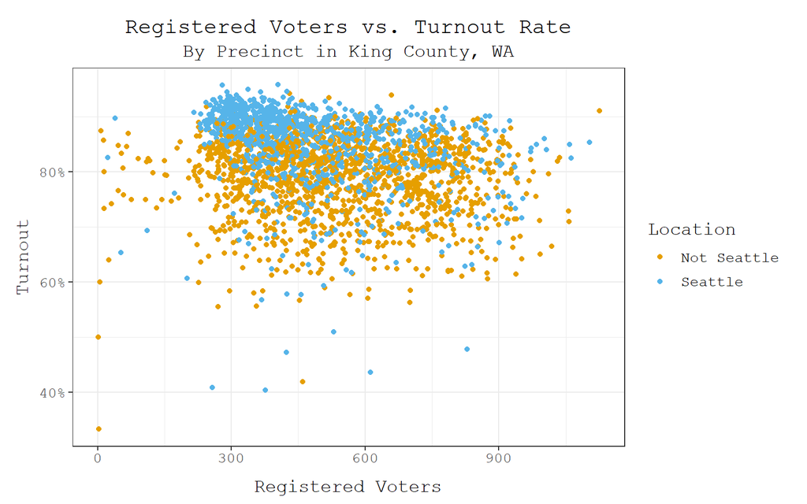

```r
#plot
ggplot(data = final_stats,
       aes(x = `Registered Voters`, y = Turnout, color = Location)) +
    geom_point() +
    scale_color_manual(values = c("#E69F00", "#56B4E9")) +
    scale_y_continuous(labels = scales::percent) +
    ggtitle(label = "Registered Voters vs. Turnout Rate",
            subtitle = "By Precinct in King County, WA") +
    theme_bw() +
    theme(plot.title = element_text(hjust = 0.5),
          plot.subtitle = element_text(hjust = 0.5),
          text = element_text(size = 13, family = "mono"),
          axis.title.x = element_text(vjust = -2),
          axis.title.y = element_text(vjust = 2),
          plot.margin = unit(c(0.5,0.5,0.5,0.5), "cm"))
```

### Democratic support

> Now let’s visualize the Democratic support rates for the three races within each precinct for sufficently large precincts. Limit the data to precincts with at least 500 registered voters (use `filter()`). Make a line plot where the horizontal axis (`x=`) indicates precincts, and the vertical axis (`y=`) shows the Democratic support rates. There should be three lines in different colors (one for each race of interest).

> **Do not** *label* the precincts on the horizontal axis: `scale_x_discrete(breaks=NULL)` is one method for doing this. You should, however, *arrange them on the axis in order from smallest to largest* in terms of support for the Democratic candidate for president—that is, the line plotting percentage support for Obama should be smoothly increasing from left to right. The order of the lines in the legend should follow the order of the lines at the right edge of the plot.

> To do this, we need to use the “wide” version of the data (one row per precinct), and order `Precinct` based on Democratic support for the Presidential race (Hint: You will probably want to use `forcats::fct_reorder()` on `Precinct`). Then we can reshape back from “wide” to “tidy” form using `pivot_longer()` so that we have one variable giving the race—and another giving vote percentage—and can plot a separate line for each race.

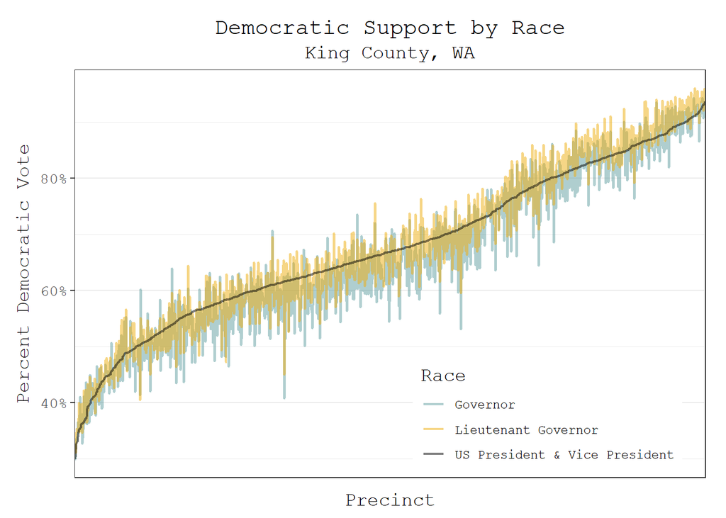

```r
#subsetting data and pivoting
long_demsupport <- final_stats %>%
    filter(`Registered Voters` >= 500) %>%
    mutate(Precint = factor(Precinct)) %>%
    mutate(Precinct = fct_reorder(Precinct, `US President & Vice President`, min)) %>%
    pivot_longer(6:8, names_to = "Race", values_to = "PctDemVote")

#graph
ggplot(data = long_demsupport,
       aes(x = Precinct, y = PctDemVote, group = Race)) +
    geom_line(alpha = 0.5, aes(color = Race), size = 0.75) +
    scale_x_discrete(breaks = NULL) +
    scale_y_continuous(labels = scales::percent) +
    scale_color_manual(values = c("cadetblue", "darkgoldenrod2", "black")) +
    ggtitle(label = "Democratic Support by Race",
            subtitle = "King County, WA") +
    ylab("Percent Democratic Vote") +
    theme_bw() +
    theme(plot.title = element_text(hjust = 0.5),
          plot.subtitle = element_text(hjust = 0.5),
          text = element_text(size = 13, family = "mono"),
          axis.title.x = element_text(vjust = -2),
          axis.title.y = element_text(vjust = 2),
          plot.margin = unit(c(0.5,0.5,0.5,0.5), "cm"),
          legend.position = c(0.75, 0.15),
          legend.text = element_text(size = 9))
```